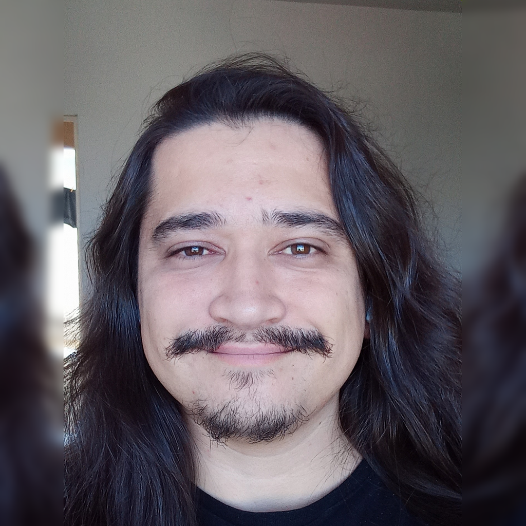

# About | Sobre

[GitHub](https://github.com/bonijoao) [LinkedIn](https://linkedin.com/in/seu-perfil)

[figure not shown]

ORCID

[figure not shown]

Lattes

**English**

### João Paulo Assis Bonifácio

Physicist with a B.Ed. from Universidade Federal de Itajubá (**UNIFEI**), currently pursuing a B.Sc. in Statistics and an M.Sc. in Statistics and Agricultural Experimentation at Universidade Federal de Lavras (**UFLA**), supported by a **CNPq** graduate scholarship.

My research and professional work focus on **Applied Statistics**, **Predictive Modeling**, **Time Series Analysis** (with emphasis on agricultural markets and animal nutrition), **Concept Drift** detection, and **Business Intelligence (BI)**.

### Academic Background

- **M.Sc. in Statistics and Agricultural Experimentation** (2024 – Present)  
  *Universidade Federal de Lavras (UFLA)*
  - CNPq Graduate Scholar.
  - Advisor: Prof. Dr. Geraldo Magela da Cruz Pereira.
- **B.Sc. in Statistics** (In progress)  
  *Universidade Federal de Lavras (UFLA)*
- **B.Ed. in Physics** (2016 – 2021)  
  *Universidade Federal de Itajubá (UNIFEI)*
  - B.Ed. Thesis: *Theoretical Frameworks of Rural Education Studies Presented at SNEF from 2001 to 2021*.
  - Advisor: Prof. Dr. Newton de Figueiredo Filho.

### Technological Projects, Software & R Packages

#### INPI Registered Software

- **Brazilian Corn Market Monitoring Dashboard** (2026)  
  *INPI Registration*: No. `512026000422-5`  
  *Authors*: Izabela Regina Cardoso de Oliveira, Sergio Domingos Simão, João Paulo Assis Bonifácio.

#### CRAN R Packages

1. **[`deriva`](https://CRAN.R-project.org/package=deriva)**: *Tidy Drift Detection for Monitored Machine Learning Models* (2026).  
   Tidy tools and numerical methods in R for monitoring and detecting concept drift in machine learning models.
2. **[`tidyprf`](https://CRAN.R-project.org/package=tidyprf)**: *Organized Access to Brazilian Federal Highway Police Data* (2026).  
   R package built under the *tidyverse* philosophy for structured extraction of public PRF data.
3. **[`figsr`](https://CRAN.R-project.org/package=figsr)**: *Fast Interpretable Greedy-Tree Sums for Tree Ensembles* (2026).  
   Implementation of the FIGS algorithm in R, fitting additive tree sums that stay readable as IF-THEN rules and integrate with *tidymodels*.

#### Development Projects

- **Animal Nutrition Products Market: Price Modeling, Forecasting, and Interactive Dashboard Implementation** (2024 – 2025)  
  Predictive price modeling for animal nutrition commodities and interactive Shiny dashboards for decision support.

### Extension Projects

- **PET Conexões de Saberes: STEM Teacher Training** (2020 – 2021) — UNIFEI
- **Semi-Presencial Course Design with Technological Support** (2018) — UNIFEI (Coordinator)
- **PIBID — Institutional Teaching Initiation Scholarship Program** (2017 – 2019) — UNIFEI
- **CATS — Theodomiro Santiago Assistential Course** (2016 – 2017) — Community pre-university prep course at UNIFEI

### Complementary Education

- **Data Analysis in R** (20h) — ENAP (National School of Public Administration), 2026.
- **Data Governance** (30h) — ENAP, 2026.
- **Python Programming** (40h) — FIAP University Center, 2022.
- **Understanding Latin America Reading Program** (60h) — Federal University of Santa Catarina (UFSC), 2020.
- **H5P in Moodle — Interactive Content** (2h) — UNIFEI, 2018.

### Technical Skills

R Language Machine Learning Time Series Concept Drift CRAN Packages R Shiny Statistical Modeling Data Governance Python Quarto / R Markdown Git & GitHub

### Languages

- **Portuguese**: Native speaker.
- **English**: Intermediate (Reading, Writing, Listening, Speaking).

João BonifácioSuper

@JoohBonny

🔥1,281

Day streak

since Mar 2023

⚡233,475

Total XP

📅2016

Member since

Learning

ENEnglish180,105 XP

Updated 2026-10-26

### Academic Links

- **ORCID**: 0009-0009-2335-8391
- **Lattes Curriculum**: http://lattes.cnpq.br/5140906846177048

**Português**

### João Paulo Assis Bonifácio

Sou Físico formado pela Universidade Federal de Itajubá (**UNIFEI**), Bacharelando em Estatística e Mestrando em Estatística e Experimentação Agropecuária na Universidade Federal de Lavras (**UFLA**), atuando como bolsista do **CNPq**.

Minhas pesquisas e atuação profissional concentram-se em **Estatística Aplicada**, **Modelagem Preditiva**, **Análise de Séries Temporais** (com foco no mercado agrícola e nutrição animal), estudo de **Concept Drift** e **Business Intelligence (BI)**. Além disso, desenvolvo ferramentas de código aberto em R com pacotes publicados no CRAN, aplicativos em Shiny e softwares com registro no INPI.

### Formação Acadêmica

- **Mestrado em Estatística e Experimentação Agropecuária** (2024 – Presente)  
  *Universidade Federal de Lavras (UFLA)*
  - Bolsista do Conselho Nacional de Desenvolvimento Científico e Tecnológico (CNPq).
  - Orientador: Prof. Dr. Geraldo Magela da Cruz Pereira.
- **Graduação em Estatística** (Em andamento)  
  *Universidade Federal de Lavras (UFLA)*
- **Graduação em Física** (2016 – 2021)  
  *Universidade Federal de Itajubá (UNIFEI)*
  - Trabalho de Conclusão de Curso: *Os Referenciais Teóricos dos Trabalhos sobre Educação do Campo Apresentados no SNEF de 2001 a 2021*.
  - Orientador: Prof. Dr. Newton de Figueiredo Filho.

### Atuação Profissional & Experiência de Trabalho

- **Universidade Federal de Lavras (UFLA)** (2024 – Presente)  
  *Bolsista de Mestrado / Pesquisador (CNPq)*  
  Atuação em pesquisa focada em estatística aplicada a dados agrícolas, análise de séries temporais e modelagem preditiva para o mercado agropecuário.
- **Fundação Instituto Brasileiro de Geografia e Estatística (IBGE)** (2022)  
  *Agente Censitário Supervisor (ACS)*  
  Supervisão de equipes de campo, controle de qualidade de dados censitários e suporte logístico/operacional.
- **Rede Estadual de Ensino de Minas Gerais** (2020 – 2023)  
  *EE Coronel Casimiro Osorio & EE Florival Xavier — Professor de Educação Básica*  
  Docência na disciplina de Física e ciências exatas no ensino fundamental e médio.
- **Cursinho Assistencial CACIC** (2023)  
  *Professor de Física (Voluntário)*  
  Preparação de estudantes em situação de vulnerabilidade para exames pré-vestibulares.
- **Universidade Federal de Itajubá (UNIFEI)** (2020 – 2021)  
  *Bolsista de Iniciação Científica (PET Conexões de Saberes)*  
  Atuação no projeto “Formação de Professores em Ciências Exatas”.

### Projetos Tecnológicos, Softwares & Pacotes R

#### Softwares Registrados (INPI)

- **Painel de Monitoramento do Mercado de Milho no Brasil** (2026)  
  *Registro INPI*: nº `512026000422-5`  
  *Autores*: Izabela Regina Cardoso de Oliveira, Sergio Domingos Simão, João Paulo Assis Bonifácio.

#### Pacotes R Publicados no CRAN

1. **[`deriva`](https://CRAN.R-project.org/package=deriva)**: *Tidy Drift Detection for Monitored Machine Learning Models* (2026).  
   Ferramentas e métodos em R para monitoramento e detecção de concept drift em modelos de machine learning.
2. **[`tidyprf`](https://CRAN.R-project.org/package=tidyprf)**: *Acesso Organizado aos Dados da Polícia Rodoviária Federal (PRF)* (2026).  
   Pacote desenvolvido sob a filosofia *tidyverse* para extração e estruturação eficiente dos dados públicos da PRF.
3. **[`figsr`](https://CRAN.R-project.org/package=figsr)**: *Fast Interpretable Greedy-Tree Sums for Tree Ensembles* (2026).  
   Implementação do algoritmo FIGS em R, ajustando somas aditivas de árvores interpretáveis como regras SE-ENTÃO e integradas ao *tidymodels*.

#### Projetos de Desenvolvimento

- **O Mercado de Produtos para Nutrição Animal: Modelagem e Predição de Preços, e Implementação de Soluções em Painéis Interativos** (2024 – 2025)  
  Desenvolvimento de modelos preditivos para commodities de nutrição animal e dashboards interativos para suporte à decisão.

### Projetos de Extensão

- **PET Conexões de Saberes: Formação de Professores em Ciências Exatas** (2020 – 2021) — UNIFEI
- **Projeto para Elaboração de Disciplinas Semipresenciais com Suporte Tecnológico** (2018) — UNIFEI (Coordenador)
- **Programa Institucional de Bolsa de Iniciação à Docência (PIBID)** (2017 – 2019) — UNIFEI
- **Curso Assistencial Theodomiro Santiago (CATS)** (2016 – 2017) — Cursinho pré-vestibular comunitário da UNIFEI

### Formação Complementar

- **Análise de Dados em Linguagem R** (20h) — Escola Nacional de Administração Pública (ENAP), 2026.
- **Governança de Dados** (30h) — Escola Nacional de Administração Pública (ENAP), 2026.
- **Programação em Python** (40h) — FIAP - Centro Universitário, 2022.
- **O que ler para entender a América Latina** (60h) — Universidade Federal de Santa Catarina (UFSC), 2020.
- **H5P no Moodle — Conteúdos Interativos** (2h) — Universidade Federal de Itajubá (UNIFEI), 2018.

### Habilidades Técnicas

Linguagem R Machine Learning Séries Temporais Concept Drift Pacotes CRAN R Shiny Modelagem Estatística Governança de Dados Python Quarto / R Markdown Git & GitHub

### Idiomas

- **Português**: Língua materna.
- **Inglês**: Intermediário (Leitura, Escrita, Compreensão e Conversação).

João BonifácioSuper

@JoohBonny

🔥1.281

Ofensiva

desde mar 2023

⚡233.475

XP total

📅2016

Membro desde

Aprendendo

ENInglês180.105 XP

Atualizado 2026-10-26

### Links Acadêmicos & Científicos

- **ORCID**: 0009-0009-2335-8391
- **Currículo Lattes**: http://lattes.cnpq.br/5140906846177048